# Silent Numbers: The Global Story of Child Mortality (Age 10 - 14)

Author

Prashant Negi DCU Id - 14694

The Tableau version of this report can be found in **[Click here](https://public.tableau.com/app/profile/prashant.negi6873/viz/BAA1030DataAnalyticsStoryTellingAssignmentbyPrashantNegi/Dashboard12)**

# Introduction

The report investigates mortality statistics for children between 10 and 14 years old which occur all over the world. It investigates how children’s death rates change across regions and change in both historical and present times and between GDP measures. This analysis displays four visual representations which consist of a choropleth map and bar chart and line graph and scatterplot with regression for discovering critical trends.

## Where are Childern most at Risk?

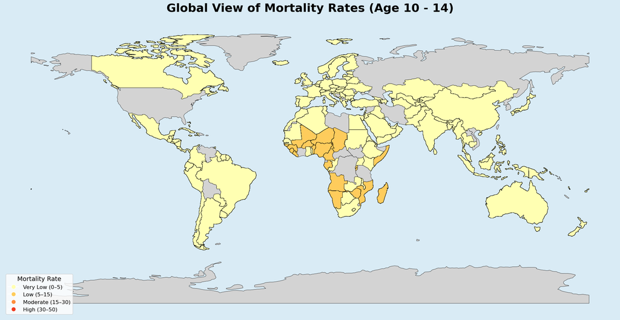

## Have we made Progress?

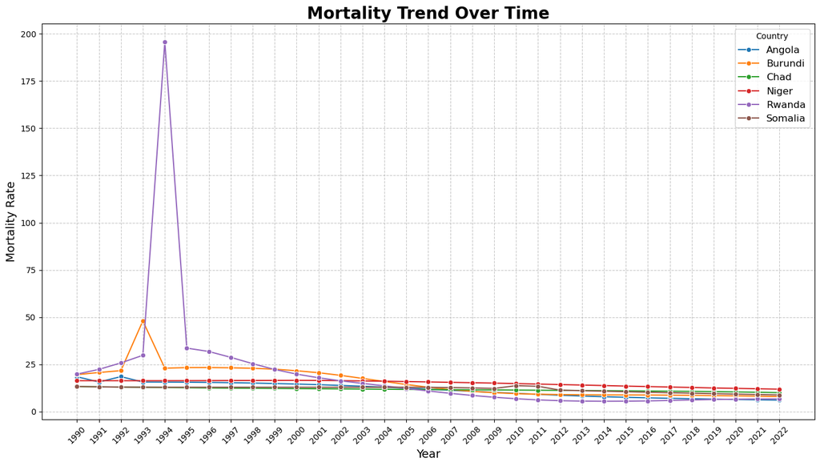

## Can Money Save Lives?

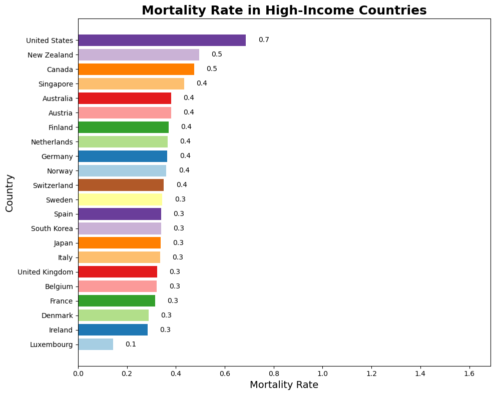

**Key Insights:**

- Mortality rates are *exceptionally low* in high-income countries, ranging from *0.1 to 0.7 deaths per 1,000 children* aged 10–14.
- **The United States** records the highest mortality among these countries (0.7), surpassing nations like *Japan* (0.3), *Switzerland* (0.4), and *Sweden* (0.3).
- **Luxembourg** stands out with the *lowest mortality rate* at 0.1, highlighting the impact of healthcare policies and social systems even within wealthy nations.
- The general *uniformity of low mortality* underscores **public health successes** across these countries, though minor differences still reveal areas for improvement.

## Socio-Economic Correlation: GDP and Mortality

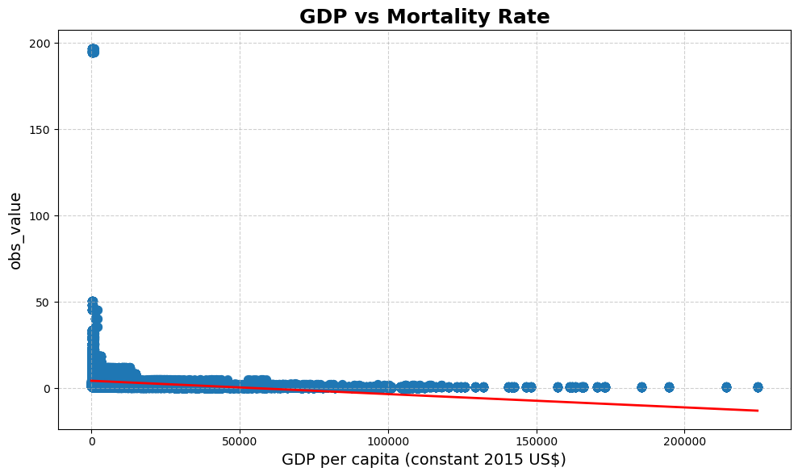

**Key Insights:**

- There is a **clear negative correlation** — as *GDP per capita increases*, *child mortality rates decrease*.
- Among *very high-income countries*, the relationship *plateaus*, indicating that *beyond a certain wealth threshold*, further GDP gains have a *diminishing impact* on mortality.
- In lower-income countries, the *spread is wider*: some achieve better outcomes than others despite similar GDP levels, highlighting that income alone does not guarantee better health.
- The **overall downward trend** affirms the role of *economic development*, but the *variance among low-GDP countries* emphasizes that **governance, healthcare access, education, and stability** are equally vital.

# Conclusion

The combination of **economic success** and solid health care infrastructure and political constancy leads to the least death rates among children between ages 10 and 14. The world sees **declining** mortality rates yet major disparities persist chiefly in **Sub-Saharan Africa** together with places tainted by conflict. Economic development clearly decreases mortality levels yet sustains these benefits only through combined implementation of peace as well as effective governance and accessible healthcare and social services.

The urgent requirement involves targeted financial investments in combination with **international collaboration** and **development policies** that welcome everyone so that every child has both survival options and growth opportunities regardless of their geographical position.

## Appendix: Full Code Snippets

**Full Python Code**

```python
import pandas as pd
import geopandas as gpd
import pandas as pd
import matplotlib.pyplot as plt
import matplotlib.colors as mcolors
from matplotlib.lines import Line2D
import seaborn as sns
import pycountry

# Load datasets
data1 = pd.read_csv('../data/unicef_indicator_1.csv')
data2 = pd.read_csv('../data/unicef_indicator_2.csv')
metadata = pd.read_csv('../data/unicef_metadata.csv')

# Load world shapefile
world = gpd.read_file('../data/shapefiles/ne_110m_admin_0_countries/ne_110m_admin_0_countries.shp')

# Look up countires
def get_country_name(name):
    try:
        return pycountry.countries.lookup(name).name
    except LookupError:
        return name

data1['country_standardized'] = data1['country'].apply(get_country_name)

# Merge datasets and find missing countires
merged = world.merge(data1, how="left", left_on="NAME", right_on="country_standardized")
missing = merged[merged['indicator'].isna()]
print("Missing countries after merge:")
print(missing['NAME'].tolist())

# Choropleth Map
bins = [0, 5, 15, 30, 50, 1000]
labels = ['Very Low (0–5)', 'Low (5–15)', 'Moderate (15–30)', 'High (30–50)', 'Very High (50+)']

merged['mortality_bin'] = pd.cut(merged['obs_value'], bins=bins, labels=labels)

colors = ['#ffffb2', '#fecc5c', '#fd8d3c', '#f03b20', '#bd0026']
cmap = mcolors.ListedColormap(colors)

bin_to_color = dict(zip(labels, range(len(labels))))
merged['bin_idx'] = merged['mortality_bin'].map(bin_to_color)

fig, ax = plt.subplots(1, 1, figsize=(20, 10))

fig.patch.set_facecolor('#d9ebf5')
ax.set_facecolor('#d9ebf5')

merged.plot(
    column='bin_idx',
    cmap=cmap,
    linewidth=0.5,
    edgecolor='black',
    ax=ax,
    legend=False,
    missing_kwds={"color": "lightgrey", "label": "Missing Data"})

legend_elements = [Line2D([0], [0], marker='o', color='w', label=label,
                          markerfacecolor=color, markersize=10) for label, color in zip(labels, colors)]
ax.legend(handles=legend_elements, title="Mortality Rate", loc='lower left', fontsize=12, title_fontsize=14)

ax.set_title('Global View of Mortality Rates (Age 10 - 14)', fontdict={'fontsize': 26, 'fontweight': 'bold'}, pad=20)
ax.axis('off')

plt.tight_layout()
plt.show()

# Line Chart
data1['Year'] = pd.to_numeric(data1['Year'], errors='coerce')
selected_countries_from_dashboard = ['Rwanda', 'Burundi', 'Angola', 'Niger', 'Chad', 'Somalia']
data_selected = data1[data1['country'].isin(selected_countries_from_dashboard)]
mortality_trend = data_selected.groupby(['Year', 'country'])['obs_value'].mean().reset_index()

high_income_countries = [
    'United States', 'Canada', 'Germany', 'France', 'United Kingdom',
    'Japan', 'Australia', 'Switzerland', 'Sweden', 'Norway', 'Denmark',
    'Netherlands', 'Austria', 'Finland', 'Ireland', 'Singapore', 'South Korea',
    'Belgium', 'New Zealand', 'Italy', 'Spain', 'Luxembourg'
]

filtered_data = data1[data1['country'].isin(high_income_countries)]
filtered_data = filtered_data.sort_values(['country', 'Year'], ascending=[True, False]).drop_duplicates('country')
filtered_data = filtered_data.sort_values('obs_value', ascending=True)

plt.figure(figsize=(14, 8))
sns.lineplot(data=mortality_trend, x='Year', y='obs_value', hue='country', marker='o')

plt.title('Mortality Trend Over Time', fontsize=20, fontweight='bold')
plt.xlabel('Year', fontsize=14)
plt.ylabel('Mortality Rate', fontsize=14)
plt.grid(True, linestyle='--', alpha=0.7)
plt.xticks(mortality_trend['Year'].unique(), rotation=45)
plt.legend(title='Country', fontsize=12)
plt.tight_layout()

plt.show()

# Bar Chart
plt.figure(figsize=(10, 8))
bars = plt.barh(filtered_data['country'], filtered_data['obs_value'], color=plt.cm.Paired.colors)

plt.title('Mortality Rate in High-Income Countries', fontsize=18, weight='bold')
plt.xlabel('Mortality Rate', fontsize=14)
plt.ylabel('Country', fontsize=14)


for bar in bars:
    width = bar.get_width()
    plt.text(width + 0.05,
             bar.get_y() + bar.get_height()/2,
             f'{width:.1f}',
             va='center', ha='left', fontsize=10)

plt.xlim(0, filtered_data['obs_value'].max() + 1)

plt.tight_layout()
plt.show()

# Scatterplot with Regression Line
merged_data = pd.merge(
    data1,
    metadata,
    how='left',
    left_on='country',
    right_on='country'
)

def make_regression_plot(x_column, y_column='obs_value', dataset=merged_data, title=None):
    plt.figure(figsize=(10, 6))
    sns.regplot(
        x=x_column,
        y=y_column,
        data=dataset.dropna(subset=[x_column, y_column]),
        scatter_kws={'s': 50, 'alpha': 0.7},
        line_kws={'color': 'red', 'linewidth': 2}
    )
    plt.title(title if title else f'{x_column} vs {y_column}', fontsize=18, weight='bold')
    plt.xlabel(x_column, fontsize=14)
    plt.ylabel(y_column, fontsize=14)
    plt.grid(True, linestyle='--', alpha=0.6)
    plt.tight_layout()
    plt.show()

make_regression_plot('GDP per capita (constant 2015 US$)', title='GDP vs Mortality Rate')
```